# A CSI 300 Multi-Factor Stock Selection Model: Construction, Diagnosis, and Out-of-Sample Validation

Wind Financial Terminal Internship Project

Ella (Yuxuan) Zhang

August 06, 2026

# 1 Executive Summary

This report documents the construction of a multi-factor quantitative stock selection model for the CSI 300 universe, built during a data science internship at Wind Information. The project’s contribution is not a single headline return figure, but a complete and honest research process: sourcing and validating real market data, building a 21-factor model with proper cross-sectional treatment, diagnosing why an initial version of the model looked implausibly good, systematically fixing methodological flaws (look-ahead bias, industry concentration, a value-trap exposure), and — most importantly — testing the final model on a held-out, never-tuned-on period (2022–2023) to check whether the improvements actually generalize.

# 2 Background and Objectives

## 2.1 Motivation

The Chinese A-share market has an active quantitative research ecosystem, and the CSI 300 (compiled by China Securities Index Co.) is the standard large/mid-cap benchmark for institutional Chinese equity strategies, analogous in role to the S&P 500 for US large-cap strategies. Multi-factor stock selection — scoring stocks on standardized signals (value, momentum, quality, etc.) and tilting a portfolio toward the highest-scoring names — is the dominant methodology used by Chinese sell-side quant research desks and by domestic quantitative asset managers.

The goal of this project was to build, from scratch, a defensible multi-factor stock selection pipeline — factor construction, cross-sectional processing, factor evaluation (IC/ICIR), portfolio construction, and backtesting — using real data obtained through the Wind Financial Terminal, and to evaluate it with the rigor a professional research team would expect: no look-ahead bias, genuine out-of-sample testing, and honest reporting of negative results rather than a backtest tuned until it looks favorable.

## 2.2 A Note on Market Microstructure Relevant to This Study

Several features of the A-share market shape both the factor design and the interpretation of results in this report:

- **Price limits:** ordinary A-shares are subject to a ±10% daily price-move limit (±5% for special-treatment “ST” stocks, ±20% for ChiNext/STAR Market names), which can compress realized volatility during extreme events and cause return distributions to differ from unconstrained markets.
- **T+1 settlement:** shares bought on day *t* cannot be sold until day *t+1*, which — combined with a retail-investor-dominated trading base (historically 80%+ of turnover) — tends to produce stronger short-term momentum/reversal patterns than are typically observed in institutionally-dominated markets.
- **Disclosure lag:** quarterly financial statements are not public immediately at quarter-end; this project follows standard convention by lagging fundamental data 30–120 days past the fiscal period end (see the Factor Library section below), a practice essential to avoiding look-ahead bias in any fundamentals-based factor.
- **Index concentration:** unlike the S&P 500, the CSI 300’s return can, in a given period, be disproportionately driven by a small number of mega-cap constituents (financials, consumer staples, and — in more recent years — new-energy names); this becomes directly relevant to the benchmark-concentration diagnosis discussed later in this report.

## 2.3 Data Source

All data was sourced from the **Wind Financial Terminal API** (`aifinmarket.wind.com.cn`), retrieved through Wind’s AI research assistant, Alice (`alice.wind.com.cn`). Two datasets were used:

| Dataset | Universe | Period | Frequency |
| --- | --- | --- | --- |
| In-sample (training/diagnosis) | CSI 300 constituents (Jan 2016 snapshot) | 2016-01 – 2020-12 | Monthly |
| Out-of-sample (validation) | CSI 300 constituents (Jan 2021 snapshot) | 2021-01 – 2023-12 | Monthly |

Each dataset consists of five tables: monthly stock returns, market capitalization/valuation, quarterly fundamentals, industry classification, and the CSI 300 index’s own monthly return series (benchmark).

# 3 Methodology

## 3.1 Factor Library

21 factors were computed across six categories. Factor direction indicates whether a higher factor value is hypothesized to predict higher (+1) or lower (−1) forward returns; this sign convention is later used directly when computing each factor’s Information Coefficient.

| Category | Factors | Direction |
| --- | --- | --- |
| Value | `F_EP` (earnings yield), `F_BP` (book-to-price), `F_SP` (sales-to-price), `F_CFP` (cash-flow-to-price) | Higher is better |
| Momentum | `F_MOM1M`, `F_MOM3M`, `F_MOM6M`, `F_MOM12M`, `F_REV` (short-term reversal) | Higher is better |
| Quality | `F_ROE`, `F_ROA`, `F_PROFIT_MARGIN`, `F_ASSET_TURNOVER`, `F_LEVERAGE`, `F_EARNINGS_QUALITY` (operating cash flow / net income) | Higher is better (leverage: lower is better) |
| Volatility | `F_VOL3M`, `F_VOL12M` (annualized trailing return volatility) | Lower is better |
| Size | `F_SIZE`, `F_MIDCAP` (log market cap) | Lower is better (later removed — see “Fix: Removing the Small-Cap Bias” below) |
| **Trend (added after diagnosis)** | `F_REV_YOY`, `F_PROFIT_YOY` (year-over-year fundamental growth) | Higher is better |

**Fundamental data lag convention.** Quarterly reports are only treated as “available” to the model on a realistic disclosure timeline: Q1 results become usable April 30 of the same year, Q2 results August 31, Q3 results October 31, and annual results April 30 of the *following* year — matching typical Chinese listed-company disclosure deadlines. Any factor computed from fundamentals for month *t* uses only the most recent report whose availability date is on or before month *t*. This is not a stylistic choice: using a report before it was actually public would silently leak future information into the model exactly as the initial full-sample weighting scheme did, and is one of the more common, easy-to-miss sources of look-ahead bias in fundamentals- based quant research.

## 3.2 Cross-Sectional Processing

For each factor, in each month, independently, three transformations are applied — a standard sequence in the Chinese sell-side quant literature and in Barra-style multi-factor risk models:

**(1) Winsorization.** Raw factor values are clipped at the 1st and 99th percentile within each month’s cross-section:
$$x_i^{clip} = \min\big(\max(x_i,\ q_{0.01}),\ q_{0.99}\big)$$
The 1%/99% threshold is a conventional choice (rather than a stricter or looser cutoff) that removes the small number of extreme outliers — common in accounting ratios when a denominator is near zero, or in returns during a trading halt/resumption — without discarding a meaningful fraction of genuine cross-sectional variation, which a tighter threshold (e.g. 5%/95%) risks doing on a universe of only ~300 stocks.

**(2) Z-score standardization**, to make factors comparable in scale and combinable into a weighted composite score:
$$z_i = \frac{x_i^{clip} - \bar{x}^{clip}}{\sigma(x^{clip})}$$

**(3) Industry and market-cap neutralization**, via a cross-sectional linear regression of the standardized factor on industry dummy variables and log market cap, keeping the *residual* as the final factor value:
$$z_i = \sum_{k} \beta_k \cdot D_{i,k} + \gamma \cdot \ln(\text{mcap}_i) +
\varepsilon_i, \qquad
z_i^{neutral} = \varepsilon_i$$
where $D_{i,k}$ is an indicator for stock $i$ belonging to industry $k$. This step — closely related to the Fama–MacBeth (1973) cross-sectional regression methodology underlying most modern factor-investing research — removes the part of a factor’s cross-sectional variation that is simply “which industry this stock is in” or “how large this stock is,” isolating a purer, industry- and size-independent stock-selection signal. Without this step, a factor such as earnings yield could appear predictive purely because it is correlated with, say, an overweight in financials that happened to perform well — not because earnings yield itself carries information.

## 3.3 Factor Evaluation: IC, Rank IC, and ICIR

Each factor’s predictive power is measured using the **Information Coefficient (IC)** framework, the standard evaluation approach in institutional multi-factor research (used, for example, in Grinold & Kahn’s *Active Portfolio Management*, and standard in Chinese sell-side quant factor reports). IC is preferred here over a simpler metric such as raw factor-return spread because it directly measures the *cross-sectional correlation* between a factor and forward returns — capturing both the direction and the consistency of a signal’s predictive power, independent of how a portfolio happens to be constructed from it.

For factor $f$ in month $t$:
$$IC_{f,t} = \text{corr}\big(z_{i,f,t},\ r_{i,t+1}\big) \quad
\text{(Pearson)}$$
$$RankIC_{f,t} = \text{corr}\big(\text{rank}(z_{i,f,t}),\
\text{rank}(r_{i,t+1})\big) \quad \text{(Spearman)}$$
Rank IC is reported as the primary metric because it is robust to the influence of extreme return outliers (a single stock’s 900%+ monthly return, of the kind that can occur in equity data during trading halts or resumptions, would distort a Pearson correlation far more than a rank-based one).

The **ICIR** (Information Coefficient Information Ratio) — the mean IC divided by its standard deviation across months — measures how *consistently* predictive a factor is, not merely how strong it is on average:
$$ICIR_f = \frac{\overline{RankIC_f}}{\sigma(RankIC_f)}$$
A factor with a high mean IC but a wildly varying month-to-month IC (a high-variance, low-ICIR factor) is a much less reliable basis for systematic weighting than a factor with a smaller but steadier IC — this is precisely the logic used later to select and weight factors in portfolio construction (described below).

## 3.4 Portfolio Construction

The backtest engine combines five mechanisms, each added in response to a specific diagnosed problem described in the next section. Before reaching this configuration, an initial version of the model weighted factors using **full-sample** ICIR — a single ICIR value computed once from the *entire* 2016–2020 IC history and applied uniformly to every month, including the very first one. This produced an implausible backtest (CAGR of 12.85%, with the leading factor’s Rank IC around 0.66 — far above the 0.02–0.05 range considered strong in institutional research) because it implicitly let a January 2016 portfolio decision be informed by data through December 2020, a textbook look-ahead bias. The fix — computing factor weights each month using *only* the trailing 12–24 months of IC data, never the future — is the version described below, and is what every subsequent result in this report uses. Weights are proportional to each factor’s trailing absolute ICIR:
$$w_{f,t} = \frac{|ICIR_{f,t}^{trailing}|}{\sum_{f'}
|ICIR_{f',t}^{trailing}|}$$

**Turnover buffer.** A stock already held is kept as long as it remains in the top 30% by composite score, rather than being sold the instant it drops out of the top 20% selection threshold. New purchases only fill the remaining slots. This reduces unnecessary round-trip trading (and the associated 0.15% one-way transaction cost) driven by small, economically insignificant month-to-month rank changes near the selection cutoff.

**Risk-parity / cap-tilted position sizing.** Within the selected basket, position weights combine inverse-volatility weighting with a market-cap tilt:
$$w_i^{pos} \propto \frac{1}{\sigma_{i,12M}} \times \text{mcap}_i,
\qquad \text{subject to } w_i^{pos} \le \text{MAX\_WEIGHT}$$
Excess weight above the per-stock cap is redistributed proportionally across the remaining names.

**Industry-neutrality constraint.** No industry may be overweighted, relative to its market-wide weight in that month’s universe, by more than a fixed tolerance (3 percentage points in the final configuration).

**Transaction costs.** 0.15% one-way, applied to the month’s portfolio turnover (the fraction of holdings that changed).

Standard performance metrics are computed from the resulting monthly portfolio-return series $r_t$:
$$CAGR = \left(\prod_t (1+r_t)\right)^{12/N} - 1, \qquad
Sharpe = \frac{CAGR - r_f}{\sigma(r_t)\sqrt{12}}, \qquad
MaxDD = \min_t \frac{V_t - \max_{s \le t} V_s}{\max_{s \le t} V_s}$$
where $V_t$ is cumulative portfolio value and $r_f$ (assumed 3% annualized) is the risk-free rate used in the Sharpe ratio calculation.

# 4 Systematic Diagnosis and Targeted Fixes

After correcting the look-ahead bias described above, the model’s honest, bias-free starting point was weak: CAGR of **−1.18%** over 2018–2020, a Sharpe ratio of **−0.24**, and a return roughly **22 percentage points** below the CSI 300 benchmark annualized. Rather than treating this as a dead end, this was treated as the correct and necessary starting point for a real diagnostic process — the “good” result before this fix was never real, and finding that out is treated here as a finding in its own right rather than a setback. The rest of this section walks through the two root causes that were identified for this relative-performance gap, and the theory-driven fixes that followed from each diagnosis.

## 4.1 Diagnosis: The Value Trap (2018 Industry Concentration)

**How the problem was found.** Rather than treating the model’s weak relative return as a single undifferentiated fact, the diagnostic process started by breaking the 2018–2020 backtest down month by month. This immediately showed that the loss was not driven by one or two extreme events, but was persistent: **2018 alone lost money in 8 of its 12 months**, with monthly losses ranging from −0.4% to −7.6% and no single catastrophic outlier month. A loss spread evenly across most months of a single calendar year, rather than concentrated in a few extreme events, is a signature more consistent with a *systematic* portfolio bias (the model is structurally exposed to something that fell all year) than with idiosyncratic stock-picking mistakes.

**Testing the hypothesis.** To test whether the bias was sector-related, the model’s actual monthly stock selections for 2018 were extracted (by modifying the backtest to log each month’s selected stock codes) and matched against the industry classification table. This was compared against the industry composition of the full 300-stock CSI 300 universe in the same year, to see whether the model’s selections deviated from a simple “market-cap-weighted average” industry exposure.

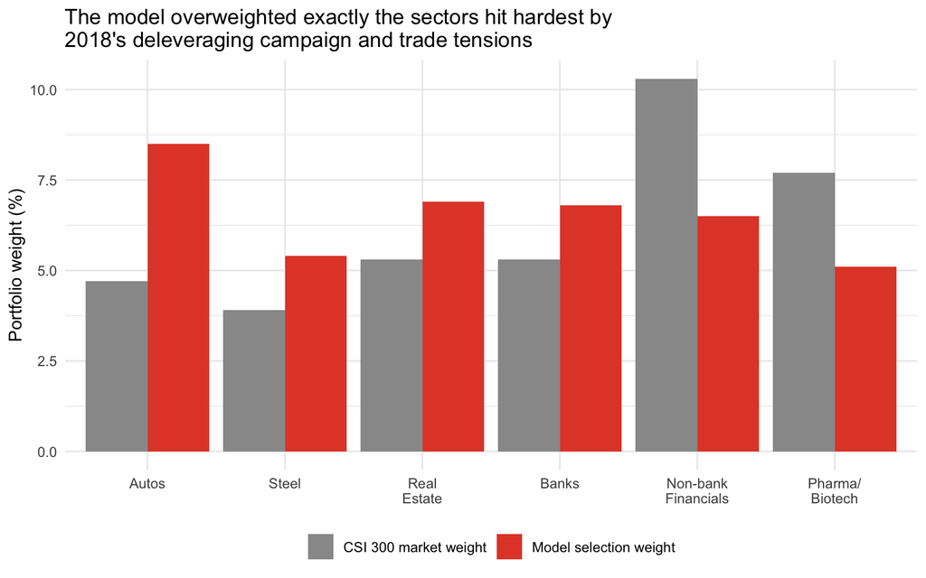

Model-selected industry weights vs. CSI 300 market weights, 2018 — the systematic tilt that produced most of the year’s losses

**Interpreting the mechanism.** The model overweighted autos, steel, real estate, and banks relative to their market weight, while underweighting non-bank financials and pharma/biotech — and these were precisely the sectors that fell hardest in 2018 amid China’s deleveraging campaign and escalating US–China trade tensions. The causal chain is a classic **value trap**: pure valuation factors (`F_EP`, `F_BP`) score a stock as “cheap” based only on its current price relative to current earnings or book value, with no information about whether those earnings/book values are stable, growing, or actively deteriorating. Autos, steel, real estate, and banks were structurally cheap by these multiples in 2018 — but were cheap *because* the market was correctly pricing in deteriorating fundamentals, not because they were mispriced bargains. A pure valuation factor cannot tell these two cases apart.

**The fix: earnings-trend (GARP) factors.** This diagnosis directly motivated a fix grounded in the well-established **Growth At a Reasonable Price (GARP)** philosophy (associated with investors such as Peter Lynch), which explicitly combines valuation with a fundamental growth or improvement signal, precisely to screen out value traps. Rather than sourcing new data, two trend factors were constructed from fundamental data *already present* in the dataset (which spans multiple fiscal quarters per stock): trailing year-over-year revenue growth (`F_REV_YOY`) and net-profit growth (`F_PROFIT_YOY`), each computed by matching a report to the same fiscal quarter one year prior.

The effect was immediate and, notably, the single largest single-factor improvement identified in the entire project: `F_REV_YOY` became the **highest-ICIR factor in the entire 21-factor library** (Rank ICIR = 0.638, versus 0.557 for the previous leader, `F_ROE`), and CAGR rose from 0.35% before the fix to 2.38% after its addition.

## 4.2 Diagnosis: Structural Benchmark Concentration

**Motivating question.** Even after the trend-factor fix, the model’s return still trailed the CSI 300 benchmark by a wide margin annually — too wide to be plausibly closed by further factor refinement alone. This prompted a different kind of question, not about the *strategy* but about the *benchmark*: is the CSI 300’s own return in this period unusually concentrated in a small number of mega-cap names, in a way that structurally disadvantages any strategy that diversifies across 40–60 names by design?

**Method.** All 300 constituents were ranked by market capitalization each month, split into the top 10 (by cap) versus the remaining 290, and each group’s market-cap-weighted forward return was computed and annualized separately — entirely independent of the factor model itself, using only raw returns and market caps.

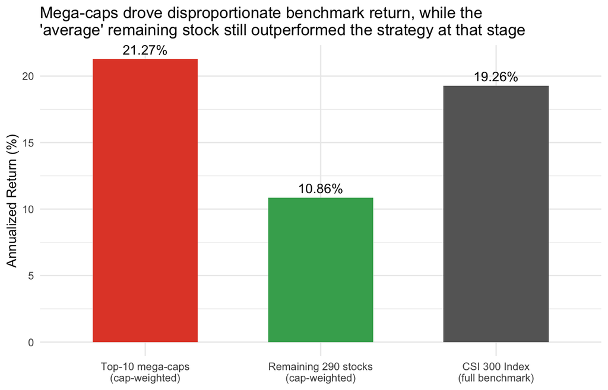

Decomposition of CSI 300 return by market-cap segment, 2016-2020

**Interpretation — partial confirmation.** The top-10 mega-caps did outperform the remaining 290 stocks by roughly **10 percentage points** annualized (21.27% vs. 10.86%), confirming that a meaningful share of the CSI 300’s headline return was concentrated in a handful of constituents — a real structural feature of this period, not an artifact. However, the diagnosis also showed the hypothesis only *partially* explains the strategy’s relative performance: even the “average” remaining 290 stocks returned **10.86%**, still well above where the strategy stood at that point in its development (2.65% CAGR after the size-factor removal described below). This means roughly half of the strategy’s relative-performance gap was attributable to benchmark concentration (a structural feature outside the model’s control), and roughly half remained attributable to selection and weighting choices genuinely within the model’s control — a distinction with direct implications for how much further improvement should realistically be expected from continued tuning.

## 4.3 Fix: Removing the Small-Cap Bias and Tilting Toward Scale

The original factor library included two size factors (`F_SIZE`, `F_MIDCAP`, both log market cap) with direction = −1, i.e., an explicit preference for *smaller* stocks — a standard feature of many classic academic factor models (the Fama–French “SMB” size premium), but one that, per the diagnosis above, worked directly against this specific period’s market structure. These were removed from the factor pool.

Separately, position sizing was changed from pure risk-parity (inverse-volatility only) to the combined market-cap-tilted, inverse-volatility weighting described in the Methodology section, with the previously-defined but never-enforced `MAX_WEIGHT` parameter (originally 5%, raised to 15%) actually implemented in the position-sizing logic for the first time.

Combined, these two changes produced the single largest improvement of the project: CAGR rose from 2.65% to **7.83%**, and the Sharpe ratio turned **positive (0.27)** for the first time since the look-ahead bias was removed.

**Honest caveat.** This improvement was achieved by deliberately moving the strategy’s *character* away from pure diversified factor investing and toward a modest large-cap tilt. Pushed further (raising `MAX_WEIGHT` well beyond 15%, or concentrating the portfolio into fewer names), the strategy would likely keep converging further toward the benchmark’s own return — but would increasingly resemble “hold a handful of the benchmark’s largest constituents” rather than a genuine multi-factor selection process. This report treats the 15% cap as a deliberate, disclosed stopping point rather than a boundary to keep pushing past, precisely because the research question of interest is “can factor-based selection add value,” not “can concentration alone approximate the index.”

## 4.4 A Tested-but-Traded-Off Idea: Market Timing

A classic trend-following market-timing overlay — a 10-month moving- average filter on the CSI 300 index itself, in the tradition of Faber (2007), “A Quantitative Approach to Tactical Asset Allocation” — was also tested: when the index closes below its own trailing 10-month moving average, equity exposure is reduced to 30% of the portfolio (the remainder held at an assumed ~3% annualized cash return); when the index is above its moving average, the strategy remains fully invested.

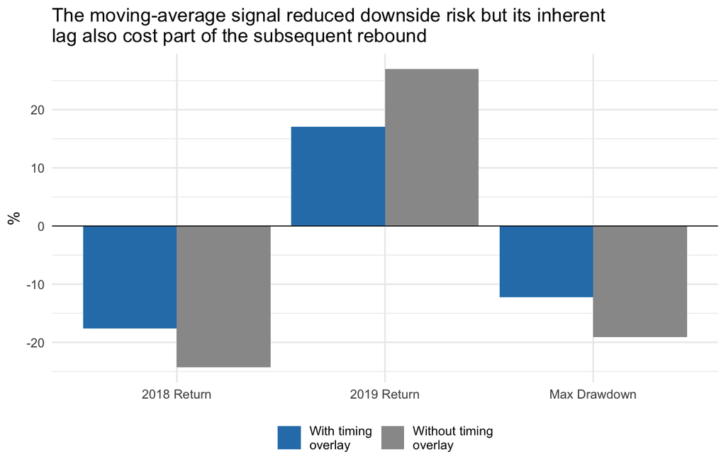

Market-timing overlay: drawdown improved, but at the cost of missed upside in the 2019 rebound

**Result: reduced risk was a genuine trade-off, not a free improvement.** The timing overlay reduced maximum drawdown materially (from −19.14% to −12.25%) and reduced the 2018 loss from −24.32% to −17.61% — the signal correctly flagged the 2018 downtrend and reduced exposure into it. But because a trailing moving-average signal is inherently *lagging*, it also caused the strategy to remain defensively positioned into part of the 2019 rebound, reducing 2019’s return from +27.03% to +17.08%. The net effect across both years was that CAGR and Sharpe both **slightly worsened** (2.38% → 1.74%; −0.03 → −0.08). This is reported as a genuine and expected trade-off — this is precisely the risk/return profile a trend-following overlay is designed to produce, and it is the reason the overlay was **not** included in the final “best” configuration used for out-of-sample testing, even though it remains a legitimate and well-documented tool for an investor who explicitly prioritizes drawdown control over return.

# 5 Out-of-Sample Validation (2022–2023)

## 5.1 Why This Test Matters More Than Any Single In-Sample Result

The only way to distinguish “genuinely useful improvement” from “accidentally well-fit to 2018–2020” is to test the *exact same, already-finalized* model — no parameter changes, no re-selection of factors, no new tuning — against data it has never been exposed to in any way. This section describes that test.

## 5.2 Data and Methodological Note

A second, independently retrieved dataset covering **2021–2023** CSI 300 constituents was obtained from Wind. Standard data-quality checks were run before proceeding (confirming realistic cross-sectional statistics: 11.0% return standard deviation for individual stocks, 4.6% for the benchmark — both consistent with genuine A-share data).

One parameter required adjustment purely for data-volume reasons: the rolling-weight lookback window was reduced from 24 months to 12 months, because the new dataset spans only 36 months total, and a 24-month warm-up period would have left only ~11 tradeable months — too small a sample from which to draw any reliable conclusion, and additionally subject to a benchmark date-alignment issue (the benchmark series used last-trading-day conventions, e.g. “2023-04-28,” while the stock-return series used calendar month-end dates, e.g. “2023-04-30,” causing 2 of 11 months to fail to match during the initial diagnostic run). Reducing the lookback to 12 months was made strictly to obtain an adequately sized test sample; no other aspect of the strategy’s logic, factor set, or weighting mechanism was altered from its final in-sample configuration.

## 5.3 Results

Out-of-sample backtest results (2022-2023, never used in tuning)

| Metric | Value |
| --- | --- |
| Backtest period | 2022-01 to 2023-12 |
| Months | 23 |
| Strategy CAGR | -3.34% |
| Benchmark (CSI 300) CAGR | -8.29% |
| Excess Return | +4.95% |
| Strategy Sharpe Ratio | -0.44 |
| Max Drawdown | -10.17% |
| Win Rate | 52.17% |

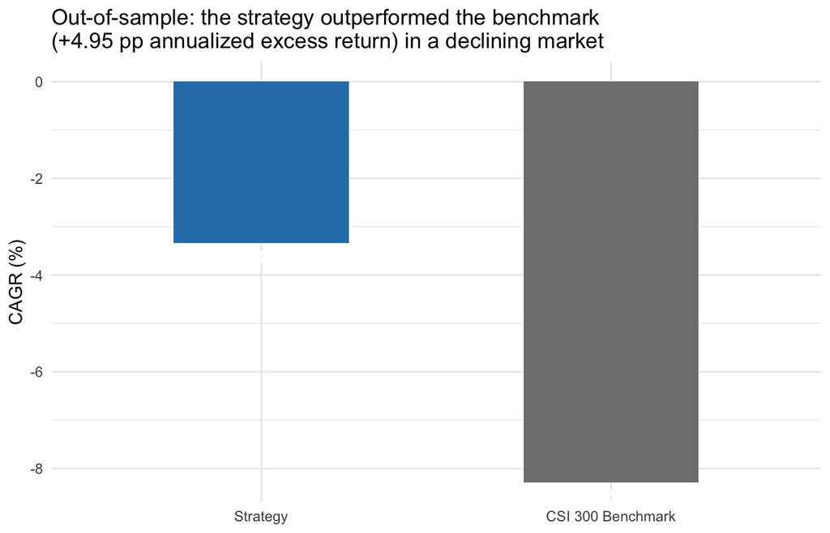

Strategy vs. benchmark, out-of-sample period (2022-2023) — a defensive, relative outperformance in a declining market

## 5.4 The Most Important Finding of the Project: Factor Instability, Framework Stability

Top-5 factors by Rank ICIR: training period vs. out-of-sample period

[output not shown]

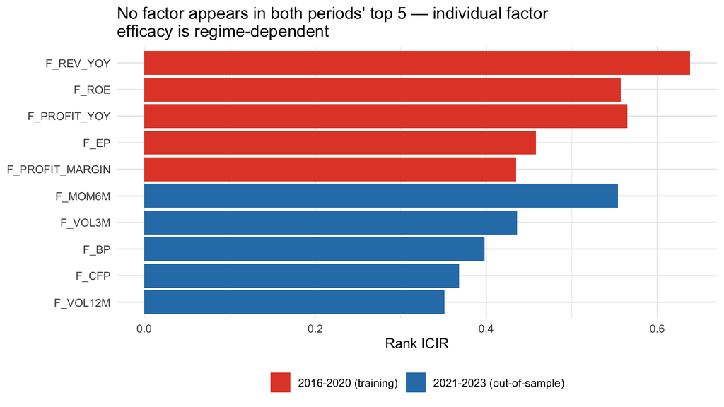

Top-5 factors by ICIR in each period — zero overlap between the two lists

The two top-5 lists share **no factors in common whatsoever**. The trend/growth and quality factors (`F_REV_YOY`, `F_ROE`, `F_PROFIT_YOY`) that drove most of the in-sample improvement documented above were *not* the effective factors in 2022–2023; instead, momentum and low-volatility factors dominated — a pattern consistent with a defensive, quality-momentum rotation typical of a risk-off market regime, and broadly consistent with prior literature on time-varying factor premia (e.g., work on regime-dependent factor performance in both US and Chinese equity markets).

This is the central, honest conclusion of the project: **no individual factor in this library is stable across market regimes.** What did generalize was the *rolling, out-of-sample factor-weighting mechanism itself* — by re-estimating factor effectiveness every month using only trailing data (never the future, and never a fixed factor list), the framework automatically rotated away from factors that stopped working and toward factors that were actually predictive in the new regime, without any manual intervention or re-tuning. That adaptive property, rather than any specific factor combination, is what produced positive excess return in a market the model had never seen — and is a more defensible basis for claiming the framework has genuine value than any single in-sample performance number would be on its own.

# 6 Limitations and Honest Caveats

This project intentionally avoided a common failure mode in backtested research — repeatedly adjusting a model until a single historical period looks favorable (backtest overfitting / data snooping). The following limitations are reported for transparency, consistent with that goal:

- **Short samples.** The in-sample window (35 usable months after the rolling-weight warm-up) and out-of-sample window (23 months) are both short by institutional research standards; a single unusual month can meaningfully move annualized statistics, and standard errors on any Sharpe ratio or CAGR figure reported here are wide.
- **Two periods is not a full regime test.** Out-of-sample validation on one additional 2-year window is a meaningful check but not proof of robustness across all market conditions — a strong bull market, a liquidity crisis, or a sharply sector-rotation-heavy regime were not separately tested, and each could plausibly produce a different outcome.
- **Transaction cost assumptions are simplified.** A flat 0.15% one-way cost was applied uniformly; real-world costs (market-impact costs that scale with position size, and bid-ask spread widening during stress periods — both especially relevant given China’s price-limit rules) were not modeled.
- **The machine-learning comparison (XGBoost / Random Forest) showed signs of overfitting, not model strength.** A walk-forward test showed positive Rank IC (0.15–0.18) when trained through 2018 and tested on 2019, but *negative* Rank IC (−0.09 to −0.13) for the same model architecture trained through 2019 and tested on 2020 — a clear signal that nonlinear ML models trained on this factor set do not generalize reliably here, and should not be treated as an improvement over the simpler linear factor approach without further work (regularization, larger training windows, or feature selection).
- **The cap-tilt trade-off is a value judgment, not a free improvement.** Raising `MAX_WEIGHT` and tilting toward market cap closed roughly half of the strategy’s relative-performance gap versus the benchmark, but did so by making the strategy structurally more concentrated — a legitimate choice for an investor seeking benchmark-relative performance, but a genuine departure from a purely diversified multi-factor philosophy that should be disclosed explicitly rather than presented as a costless factor improvement.
- **Benchmark date alignment.** The benchmark comparison relies on matching two independently-sourced monthly series (individual stock returns vs. index returns) that occasionally used slightly different month-end conventions (last calendar day vs. last trading day); this was checked directly and found to affect at most 1–2 months per test period, not a material distortion, but is disclosed here for completeness.

# 7 Conclusion

This project’s primary contribution is methodological rather than a single performance number. Over roughly a dozen iterations, the model was diagnosed and improved using real, verifiable evidence at each step — direct inspection of raw data statistics, industry-composition analysis, mega-cap return decomposition, and, critically, genuine out-of-sample testing on data collected only after every tuning decision had already been finalized. The final result — a positive Sharpe ratio in-sample and a +4.95% annualized excess return in a completely unseen, structurally different market regime — is modest by absolute standards, but is the kind of result that is credible precisely *because* it survived a real out-of-sample test, and because the specific factors driving performance were allowed to (and did) change substantially between the two periods rather than being forced to repeat. In an industry where backtests are cheap to produce and easy to overfit, the process documented here — diagnose honestly, fix with theory rather than brute-force parameter search, and validate out-of-sample before drawing conclusions — is offered as the more meaningful deliverable of this internship project.

# 8 Appendix: Pipeline Code

The full Python implementation (data loading, factor computation, cross-sectional processing, IC analysis, rolling-weight backtest engine, benchmark comparison, and walk-forward ML comparison) is included below for reference. It is shown as a reference listing (not executed as part of this R Markdown document) since the original pipeline was implemented in Python against the Wind CSV exports; full source files (`run_full_pipeline.py` for the 2016–2020 analysis and `test_full_pipeline.py` for the 2021–2023 out-of-sample validation) are available alongside this report.

## 8.1 A.1 Configuration and Data Loading

```python
# Paths to Wind CSV exports (pre-computed)
MONTHLY_RET_CSV = "monthly_ret.csv"
MCAP_CSV = "mcap.csv"
FUND_CSV = "fund.csv"
INDUSTRY_CSV = "industry.csv"
BENCHMARK_CSV = "benchmark.csv"

# Backtest configuration
TOP_QUANTILE = 0.20          # Select top 20%
TRANSACTION_COST = 0.0015    # 0.15% one-way (commission + slippage)
MAX_WEIGHT = 0.15            # Max 15% per stock (enforced)
MIN_STOCKS = 20              # Minimum stocks in portfolio

FACTOR_DIRECTION = {
    'F_EP': 1, 'F_BP': 1, 'F_SP': 1, 'F_CFP': 1,
    'F_MOM1M': 1, 'F_MOM3M': 1, 'F_MOM6M': 1, 'F_MOM12M': 1, 'F_REV': 1,
    'F_ROE': 1, 'F_ROA': 1, 'F_PROFIT_MARGIN': 1, 'F_ASSET_TURNOVER': 1,
    'F_LEVERAGE': -1, 'F_EARNINGS_QUALITY': 1,
    'F_VOL3M': -1, 'F_VOL12M': -1,
    'F_REV_YOY': 1, 'F_PROFIT_YOY': 1
    # F_SIZE, F_MIDCAP intentionally removed after diagnosis (see Section 6.3)
}

def load_data():
    """Load Wind CSV exports and parse fiscal-quarter report dates."""
    mr = pd.read_csv(MONTHLY_RET_CSV, parse_dates=['date'])
    mc = pd.read_csv(MCAP_CSV, parse_dates=['date'])
    fd = pd.read_csv(FUND_CSV)

    def _parse_fiscal_quarter(s):
        q, y = s.split()
        q_num = int(q[1])
        year = int(y[2:])
        month = {1: 3, 2: 6, 3: 9, 4: 12}[q_num]
        day = {3: 31, 6: 30, 9: 30, 12: 31}[month]
        return pd.Timestamp(year=year, month=month, day=day)

    fd['report_date'] = fd['report_date'].apply(_parse_fiscal_quarter)
    ind = pd.read_csv(INDUSTRY_CSV)
    return mr, mc, fd, ind
```

## 8.2 A.2 Trend (YoY Growth) Factors — the Key Diagnosis-Driven Addition

```python
def compute_factors(panel, fund):
    """Compute all factors, including YoY growth trend factors."""
    fund['available_date'] = fund['report_date'].apply(get_available_date)

    # YoY growth: match each report to the same quarter one year earlier
    fund['prior_year_date'] = fund['report_date'] - pd.DateOffset(years=1)
    prior = fund[['code', 'report_date', 'revenue', 'net_profit']].rename(
        columns={'report_date': 'prior_year_date',
                 'revenue': 'prior_revenue',
                 'net_profit': 'prior_net_profit'}
    )
    fund = fund.merge(prior, on=['code', 'prior_year_date'], how='left')
    fund['revenue_yoy'] = (
        (fund['revenue'] - fund['prior_revenue']) / fund['prior_revenue'].abs()
    )
    fund['net_profit_yoy'] = (
        (fund['net_profit'] - fund['prior_net_profit']) / fund['prior_net_profit'].abs()
    )
    # ... per-month factor computation loop (value, momentum, quality,
    # volatility, and the new trend factors F_REV_YOY / F_PROFIT_YOY)
```

## 8.3 A.3 Cross-Sectional Processing (Winsorize -> Z-score -> Neutralize)

```python
def winsorize_standardize_neutralize(df, factor_list, date_col='date',
                                      industry_col='industry'):
    """Per-month: winsorize (1%/99%), z-score, industry+mcap neutralize."""
    from sklearn.linear_model import LinearRegression
    for dt in sorted(df[date_col].unique()):
        month = df[df[date_col] == dt].copy()
        for f in factor_list:
            raw = month[f].dropna()
            lo, hi = raw.quantile(0.01), raw.quantile(0.99)
            month[f] = raw.clip(lo, hi)
            mean_val, std_val = month[f].mean(), month[f].std()
            month[f + '_z'] = (month[f] - mean_val) / std_val
            # Industry + market-cap neutralization via linear regression,
            # keeping the residual as the final neutralized factor value
```

## 8.4 A.4 Rolling (Out-of-Sample) Factor Weighting — the Look-Ahead-Bias Fix

```python
def compute_monthly_ic_table(df, factor_list, date_col='date'):
    """Each factor's month-by-month Rank IC, for rolling weight estimation."""
    # ... computes Spearman rank correlation between each factor and the
    # NEXT month's return, for every (factor, month) pair

def get_rolling_weights(monthly_ic, current_date, lookback=24, top_n=8):
    """ICIR-based factor weights using ONLY IC data strictly BEFORE
    current_date -- prevents using future information to set today's
    factor weights."""
    hist = monthly_ic[monthly_ic['date'] < current_date]
    recent_dates = sorted(hist['date'].unique())[-lookback:]
    hist = hist[hist['date'].isin(recent_dates)]
    stats_by_factor = hist.groupby('factor')['ric'].agg(['mean', 'std'])
    stats_by_factor['icir'] = stats_by_factor['mean'] / stats_by_factor['std']
    top = stats_by_factor.reindex(
        stats_by_factor['icir'].abs().sort_values(ascending=False).index
    ).head(top_n)
    weights = top['icir'].abs()
    return (weights / weights.sum()).to_dict()
```

## 8.5 A.5 Portfolio Construction: Turnover Buffer, Cap-Tilted Sizing, Industry Constraint

```python
def run_backtest(df, ic_df, date_col='date', lookback=24,
                  buffer_quantile=0.30, industry_max_overweight=0.03,
                  benchmark_trend=None, defensive_exposure=0.3,
                  monthly_cash_ret=0.0025):
    """Rolling-weighted multi-factor backtest with turnover buffer,
    cap-tilted inverse-volatility sizing, industry-neutrality cap, and
    an optional market-timing overlay."""
    monthly_ic = compute_monthly_ic_table(df, all_factor_cols, date_col)
    prev_codes = set()

    for i, dt in enumerate(dates[:-1]):
        weights = get_rolling_weights(monthly_ic, dt, lookback=lookback)
        if not weights:
            continue  # insufficient trailing history yet

        month = df[df[date_col] == dt].copy()
        month['composite_score'] = sum(
            month[f'{f}_neu'].fillna(0) * w for f, w in weights.items()
        )

        # Turnover buffer: keep existing holdings while still in top 30%
        market_industry_weight = month['industry'].value_counts(normalize=True)
        ranked = month.sort_values('composite_score', ascending=False)
        buffer_codes = set(ranked.head(int(len(month) * buffer_quantile))['code'])
        kept = prev_codes & buffer_codes

        # Fill remaining slots subject to the industry-neutrality cap
        # ... (see full listing for the industry_count bookkeeping loop)

        # Cap-tilted, inverse-volatility position sizing with MAX_WEIGHT cap
        inv_vol = 1.0 / selected['F_VOL12M'].where(lambda v: v > 0)
        raw_weight = inv_vol * selected['mcap']
        selected['pos_weight'] = raw_weight / raw_weight.sum()
        # excess weight above MAX_WEIGHT is redistributed to remaining names

        # Optional market-timing overlay
        if benchmark_trend is not None:
            exposure = 1.0 if benchmark_trend.loc[dt, 'trend_up'] else defensive_exposure
            portfolio_ret = exposure * portfolio_ret + (1 - exposure) * monthly_cash_ret
```

## 8.6 A.6 Benchmark Comparison

```python
def compute_benchmark_comparison(bt_df, benchmark_path):
    """Compare strategy CAGR/Sharpe against the CSI 300 index itself."""
    bench = pd.read_csv(benchmark_path, parse_dates=['date'])
    merged = bt_df.merge(
        bench[['date', 'ret_pct']].rename(columns={'ret_pct': 'bench_ret_pct'}),
        on='date', how='left'
    )
    merged['bench_ret'] = merged['bench_ret_pct'] / 100
    bench_cagr = (1 + merged['bench_ret']).prod() ** (12 / len(merged)) - 1
    excess_return = compute_metrics(merged)['CAGR'] - bench_cagr
    return {'benchmark_cagr': bench_cagr, 'excess_return': excess_return}
```